# **Exploring Potential Predictors of Postgraduate Financial Success**

### Postgraduate Earnings vs. Male Proportion

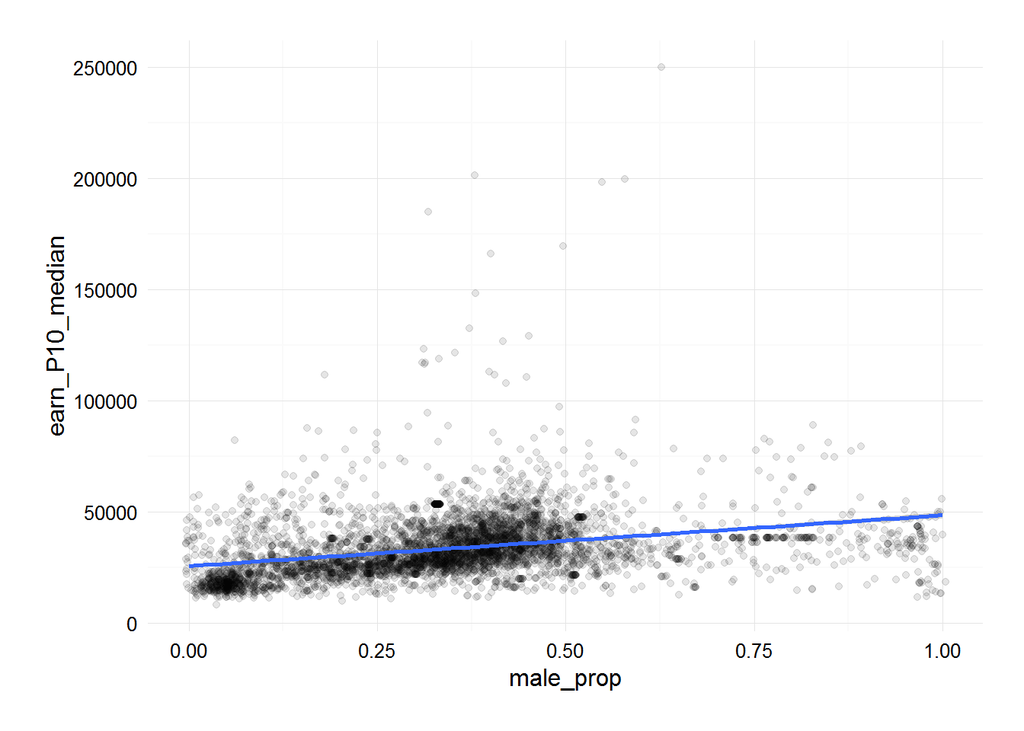

We can make several observations:

- Most observations are located on the left side of the plot, indicating female students are the majority in most institutions.
- The main cluster of observations shows an upward trend, suggesting a positive correlation between an institution’s median postgraduate earnings and proportion of male students.
- There are several potential outliers. Outliers could be expected as the distribution of the median postgraduate earnings is highly positively skewed. They do not seem to much affect our interpretation of a positive correlation as 1) they also show an upward trend and 2) outliers usually do not much change the slope of a regression line.
- There are several potential high leverage points. These include institutions whose male proportion is greater than 0.75. High leverage points have considerable influence on the slope of a regression line. In this case, we see many of them have relatively low median postgraduate earnings, which will counter the upward trend that the majority of observations show.

In sum, there seems to be an overall positive correlation between an institution’s proportion of male students and median postgraduate earnings, though some institutions do not fit into this pattern. In other words, with other things being equal, we can expect an institution with a higher proportion of male students to have higher median postgraduate earnings. But is this true?

Let’s recall that our previous investigation has identified an institution’s primary degree type as a strong indicator of its postgraduate earnings. We have also seen that this factor underlies and hence explains other relationships involving postgraduate earnings. Could it be that it also underlies (hence explains) the positive correlation between the proportion of male students and the median postgraduate earnings?

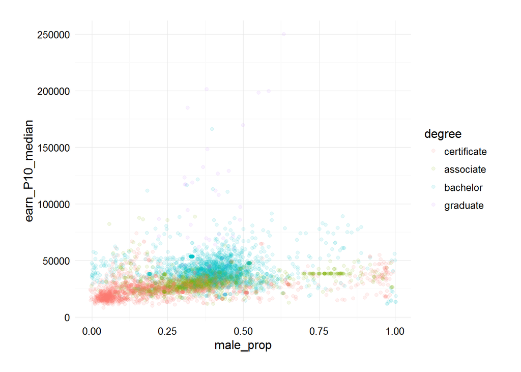

Our suspicion seems quite valid: higher level institutions tend to be located higher on *both* y- and x-axis, suggesting the upward trend between the two variables (`earn_P10_median` and `male_prop`) is largely due to their respective correlation with primary degree type (`degree`).

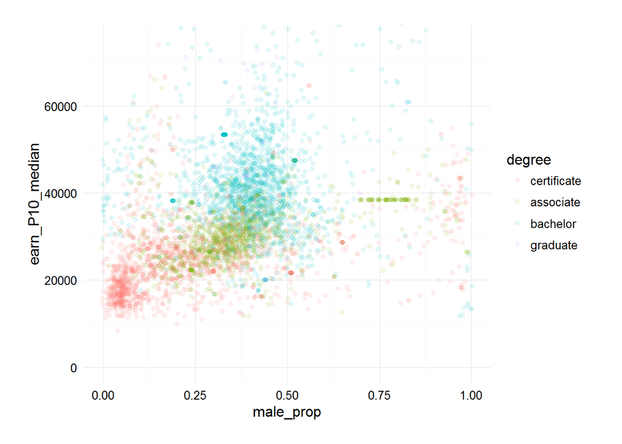

A closer look at the main cluster (`earn_P10_median` < $75,000) better reveals linearity based on the primary degree type, which further supports our earlier observation. The dot plot below makes more explicit the correlation between primary degree type and proportion of male students.

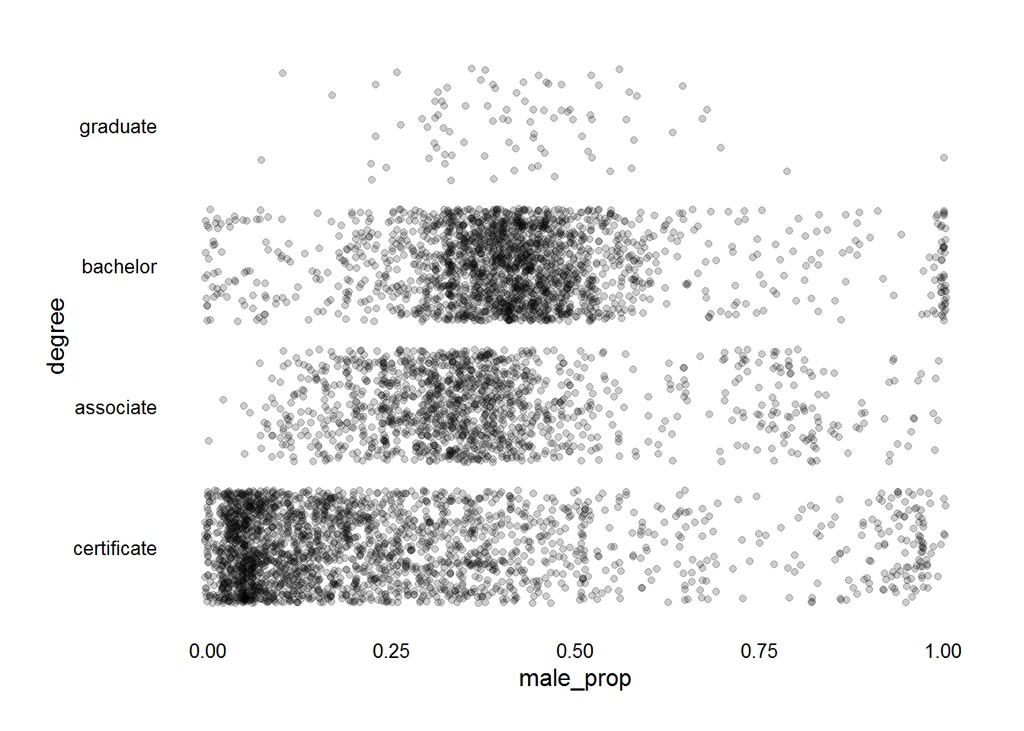

Naturally, our next step is to examine the relationship (between `earn_P10_median` and `male_prop`) after adjusting for the potential confound (i.e. `degree`).

### Postgraduate Earnings vs. Male Proportion, Adjusting for Degree Type

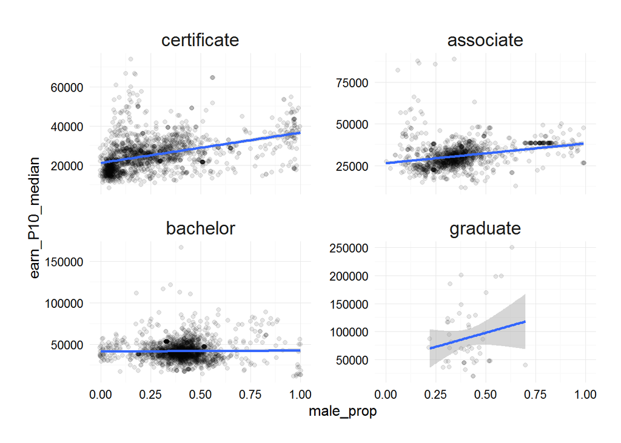

We now move to another important demographic factor, race. Is there a relationship between an institution’s racial composition and its median postgraduate earnings?

### Race and Postgraduate Earnings

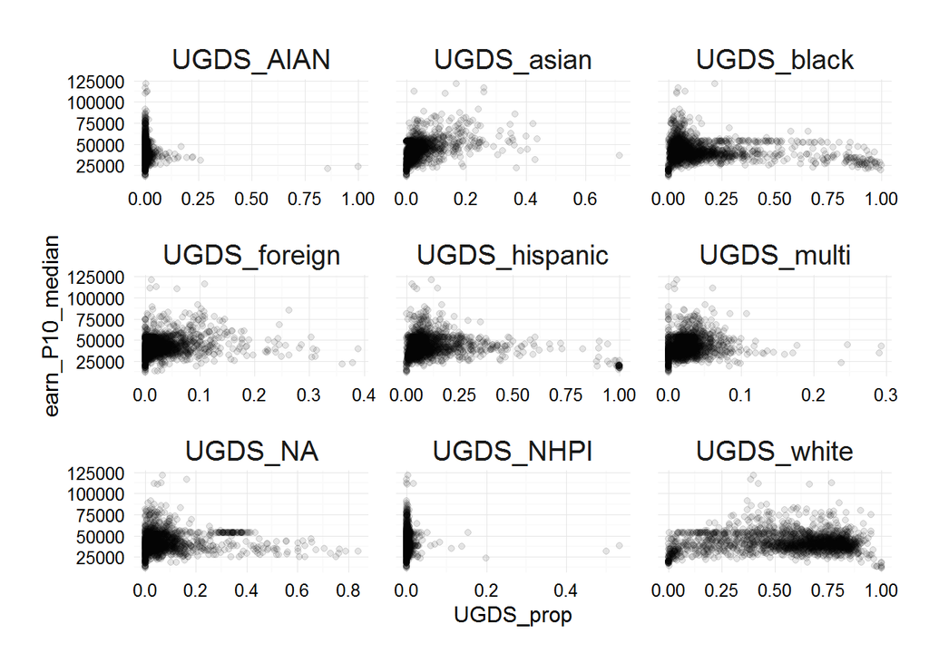

The result indicates no association between an institution’s racial composition and its level of postgraduate financial success. Note that the plot was created based on only undergraduate institutions (`bachelor`) due to availability of relevant information (i.e. racial composition). Degree type has hence been already adjusted, so our conclusion of no association becomes stronger.

Nonetheless, we can make some observations from the plot. First, white students are the majority at most undergraduate institutions (which is not much surprising; sort of a sanity check). Second, there exist some undergraduate institutions where black or Hispanic students form the majority (which should include historically black colleges).

## 4. Student Finance

We now examine how student finance relates to an institution’s postgraduate earnings, starting with the median family income. Do institutions with more affluent students have higher postgraduate earnings?

### Family Income

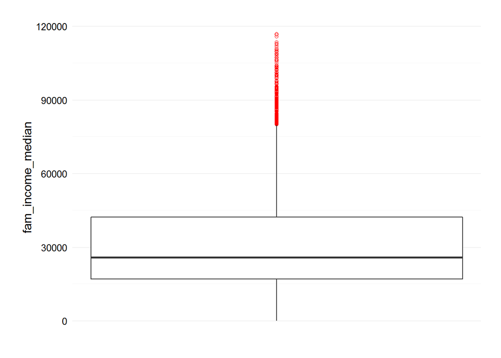

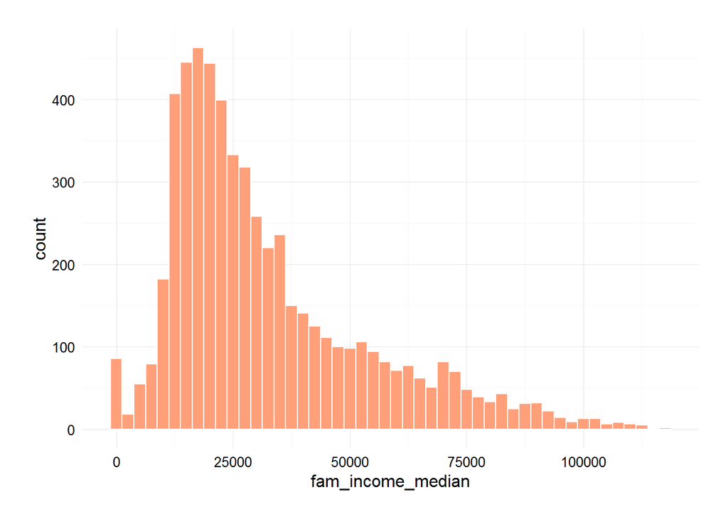

We see that the distribution of average family income is positively skewed, but to a lesser extent than some of the previous distributions. We have some outliers but they are not as glaringly extreme as those we saw in the median postgraduate earnings.

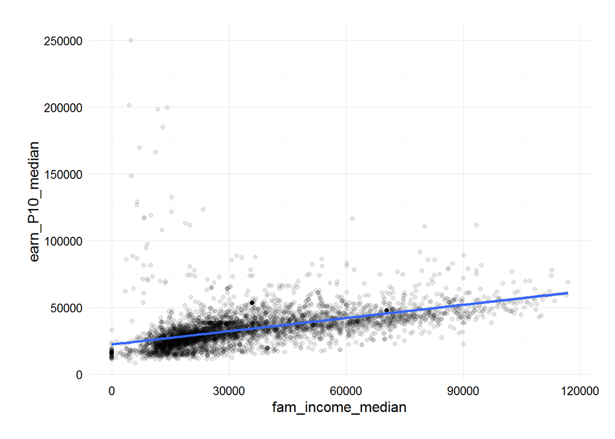

The first look seems to suggest a positive correlation. It is noteworthy, however, that there are several institutions that go against this trend, with the very low median family income but the very high postgraduate earnings. We also note that there are some institutions with the zero median family income, which does not make sense and is hence probably the result of data entry error.

As before, we take a skeptical stance and examine the relationship after adjusting for the potential confound, `degree`.

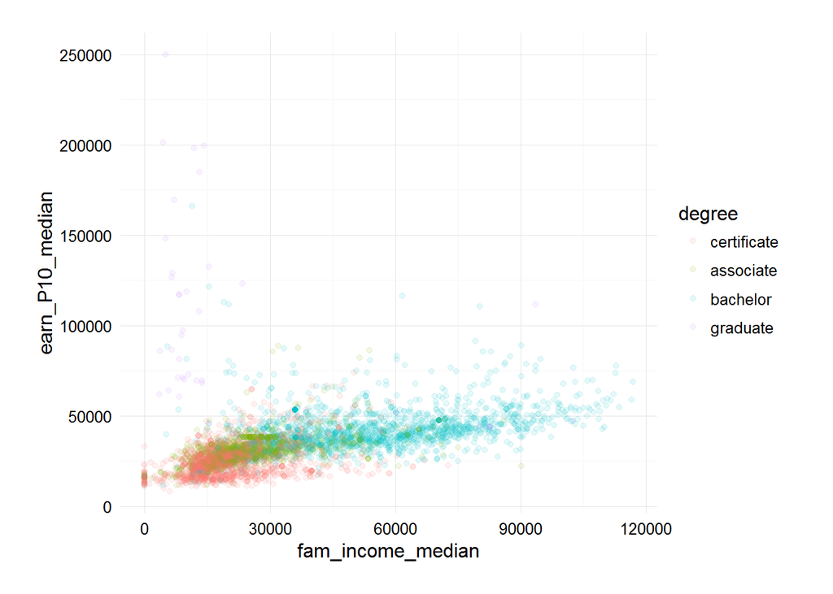

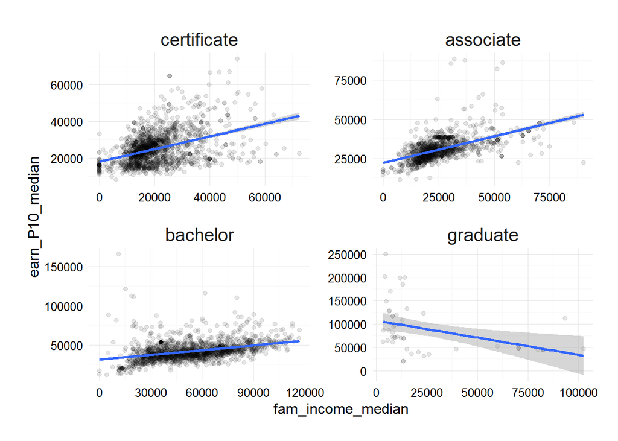

We see that the positive correlation remains in `certificate`, `associate`, and `bachelor`, but not in `graduate` institutions. Considering that the `graduate` subgroup contains relatively few data points, we may say there is some positive correlation between an institution’s overall family income level and its postgraduate earnings. That is, institutions with more affluent students seem to have higher postgraduate earnings. Yet, the strength of the correlation is quite weak, so its *practical* significance can be arguable.

Interestingly, the `graduate` subgroup includes most of the unusual institutions with the very low median family income but the very high postgraduate earnings. This suggests that the majority of students in `graduate` institutions come from poor families but end up in earning a lot. Future analysis can probe why this dramatic transformation is unique to the `graduate` subgroup.

Next, we examine the relationship between cost of attendance and postgraduate earnings.

### Cost of Attendance

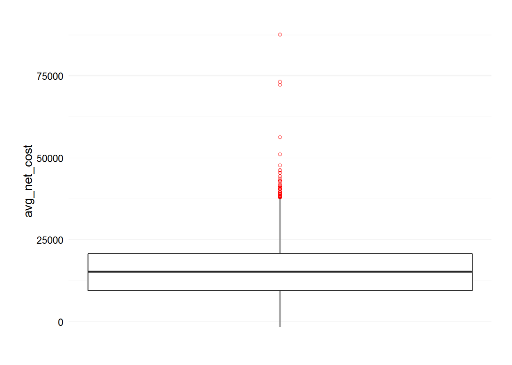

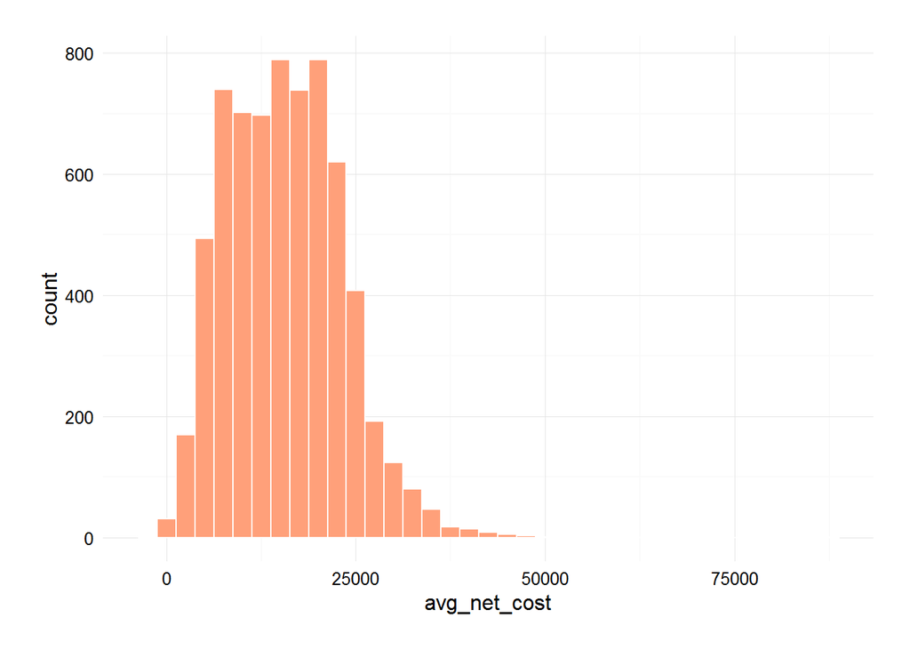

We observe a quite narrow interquartile range, which means that the average net cost of attendance is relatively similar among the middle 50% of the institutions. We can read the same trend from the histogram, whose “peak” is relatively blunt and wide.

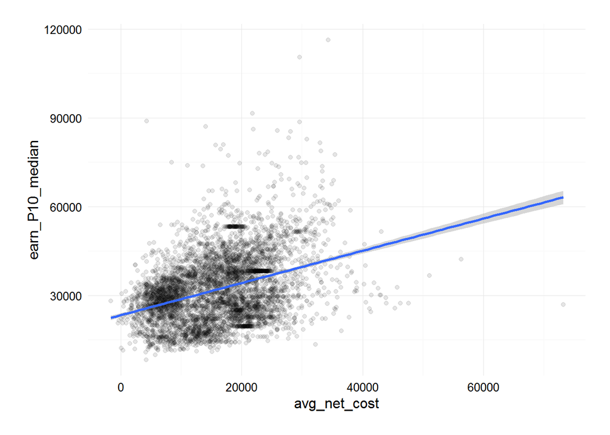

We observe some positive correlation. However, we also see some sort of subgroupings within the main cluster (indicated by different densities), which suggest the possibility of a confound.

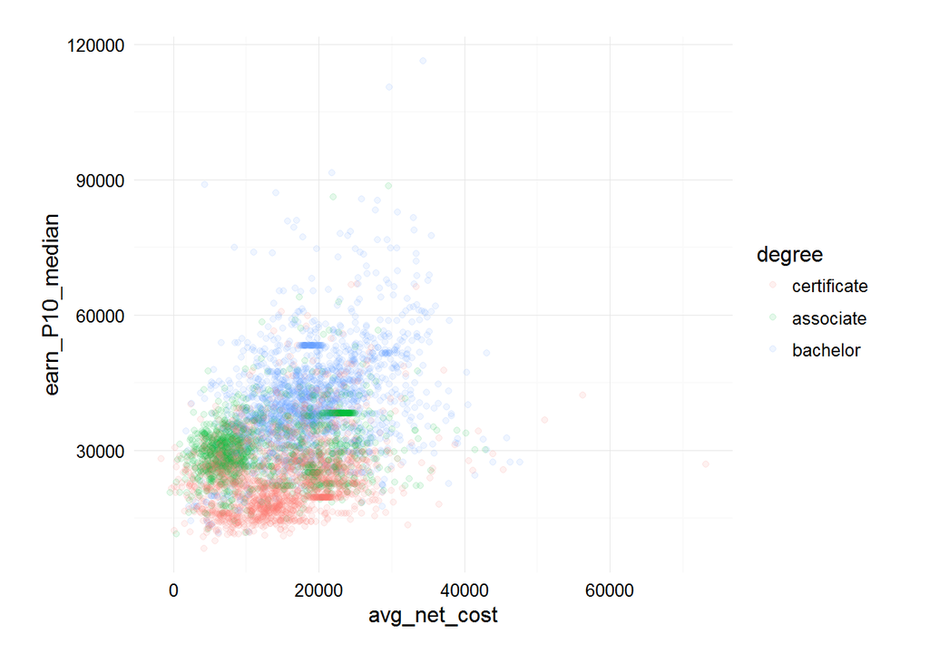

We indeed see that the main cluster is compartmentalized by primary degree type. Let’s adjust for primary degree type.

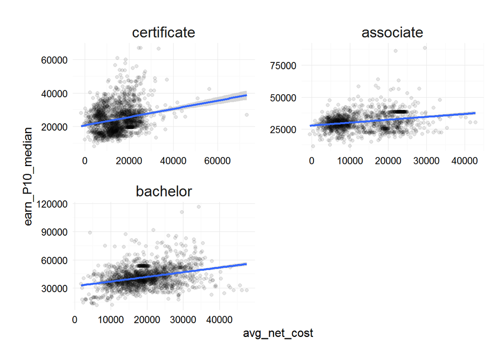

We observe that the positive correlation persists after adjusting for primary degree type. In other words, graduates of more expensive institutions tend to earn more than their counterparts who attended more affordable schools. Again, the strength of the correlation is quite weak, so its *practical* significance can be arguable.

An anomaly is worth mentioning: the plots indicate that there are some institutions whose cost of attendance (`avg_net_cost`) is less than zero. To get some information about these institutions:

```
## Source: local data frame [6 x 5]
##
##                                                  inst_name            control      degree earn_P10_median avg_net_cost
##                                                     (fctr)             (fctr)      (fctr)           (int)        (int)
## 1                          Gordon Cooper Technology Center             public certificate           28200        -1643
## 2                                            CET-El Centro  private_nonprofit certificate           21600         -264
## 3 Instituto Tecnologico de Puerto Rico-Recinto de San Juan             public   associate           20800         -445
## 4                             Thuy Princess Beauty College private_for-profit certificate              NA        -1094
## 5                                American Health Institute private_for-profit certificate              NA         -788
## 6                  Beautiful You School of Nail Technology private_for-profit certificate              NA        -1220
```

Cost of attendance being less than zero does not make sense, so these values are likely to be data entry errors. Yet, it is also possible that these negative values actually bear meanings based on initial data coding policy.

Finally, we examine how student debt relates to postgraduate earnings.

### Postgraduate Earnings vs. Student Debt

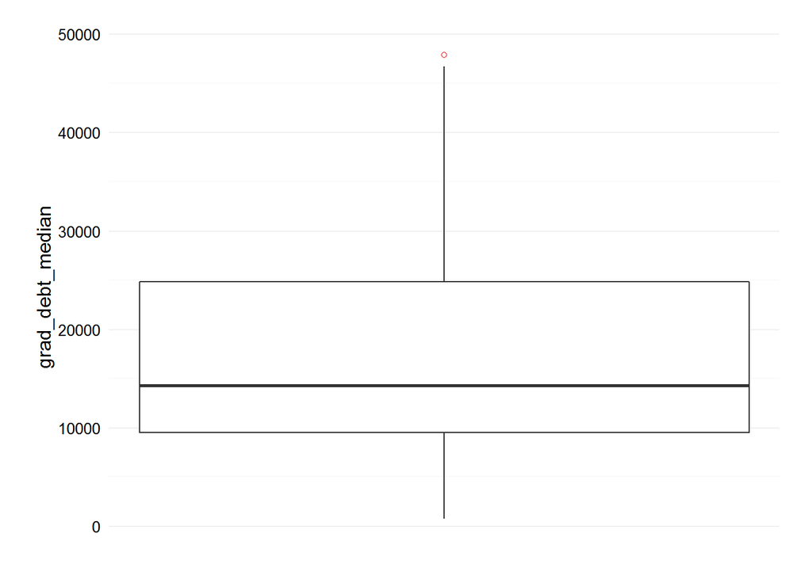

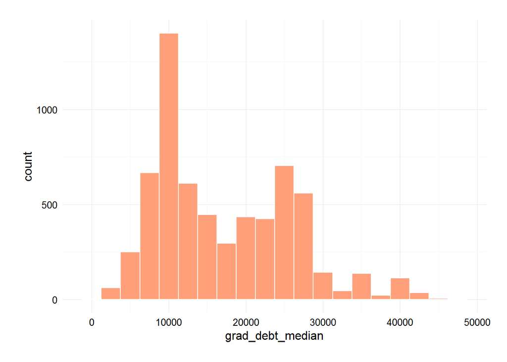

We note that the distribution of student debt across institutions is binomial and has very few outliers.

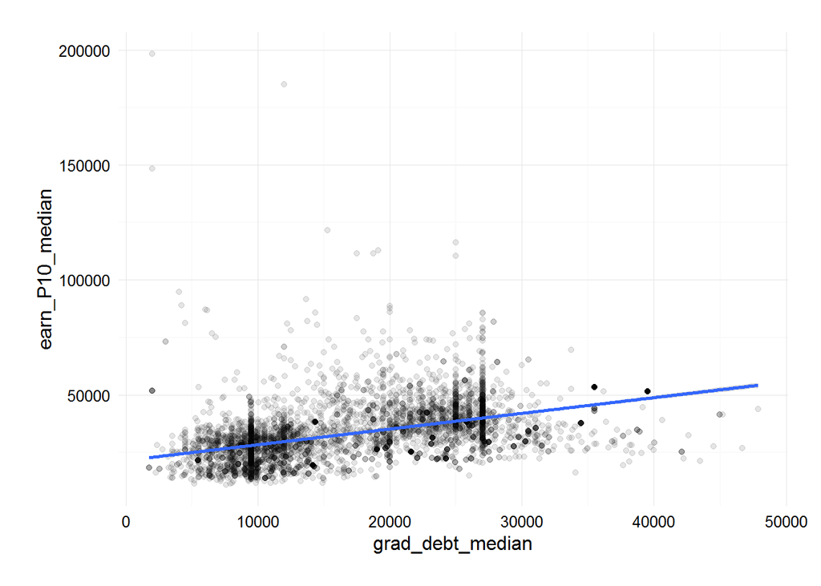

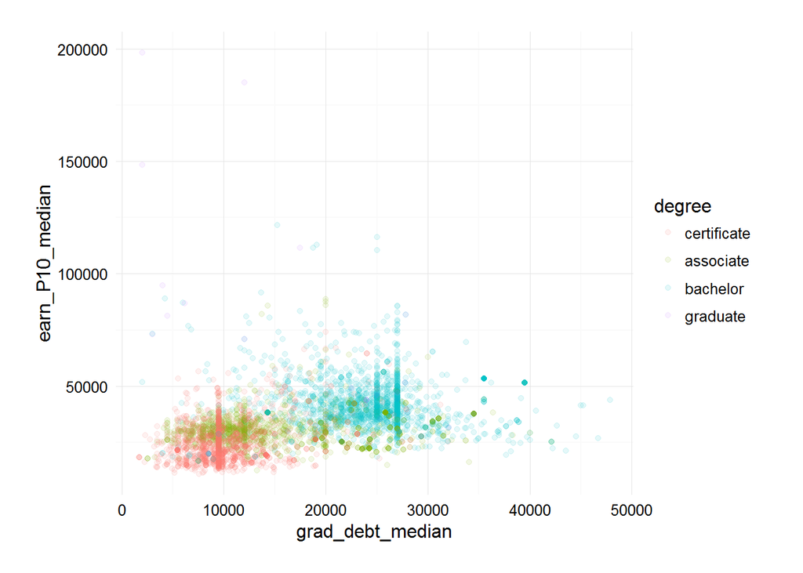

We see that each cluster corresponds to a different degree type. Let’s examine the relationship after adjusting for primary degree type.

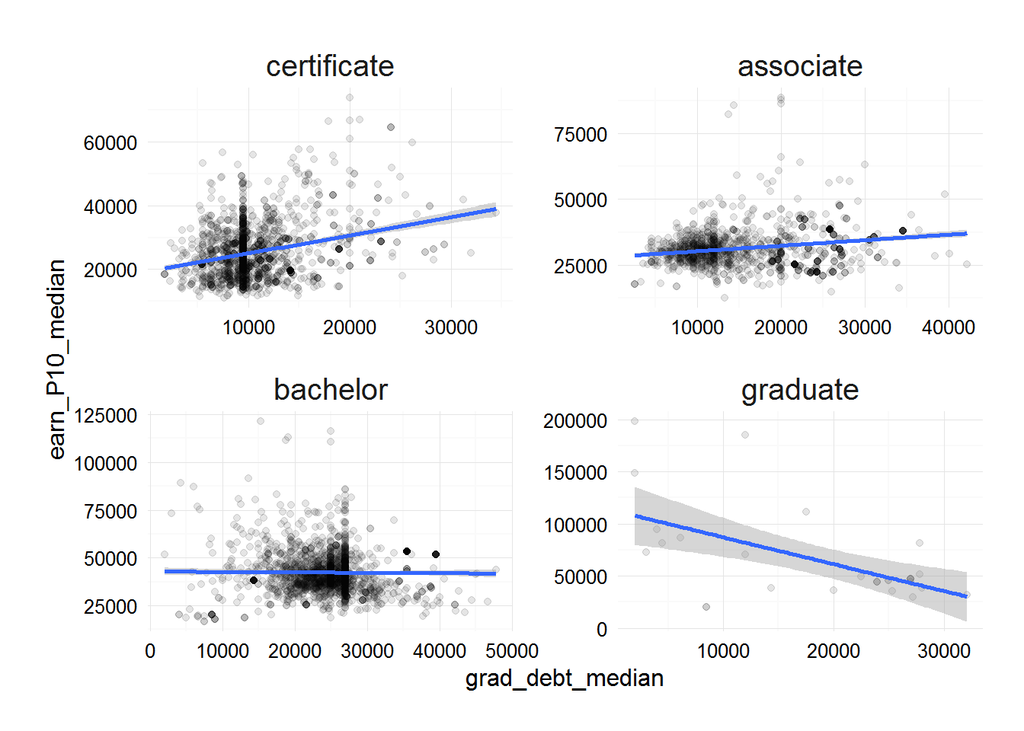

# III. Conclusion

## 1. Final Plots and Summary

### Plot One

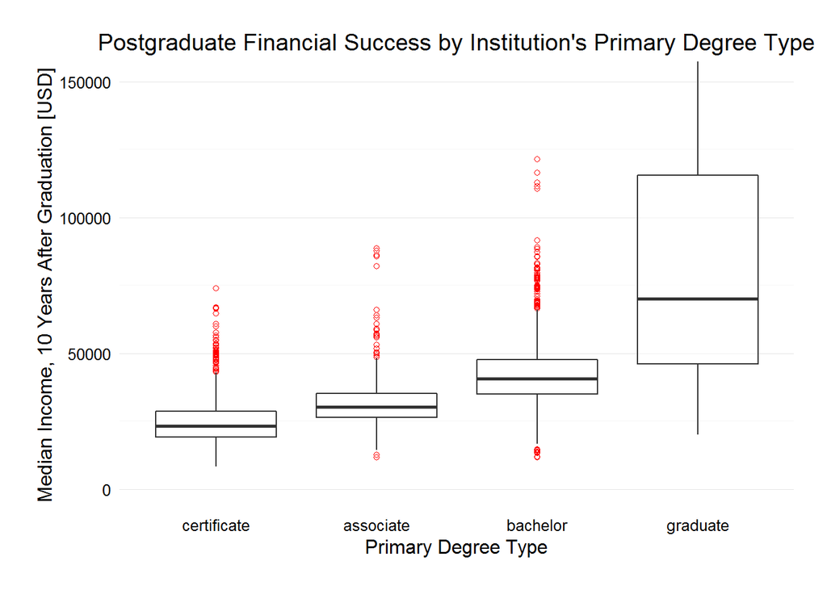

Data from higher education institutions in the U.S. in 2014 has been analyzed to identify potential indicators of postgraduate success. The plot shows distribution of institutions’ median postgraduate earnings by primary degree type. The distribution (and its median value) moves up as primary degree level goes up, indicating that institutions whose primary degree level is higher tend to have greater postgraduate financial return. It is noteworthy that graduate institutions vary more in their levels of postgraduate financial return than institutions of lower degree types/levels. Note that the plot has been zoomed in for better display, so some outliers in graduate institutions are not shown.

### Plot Two

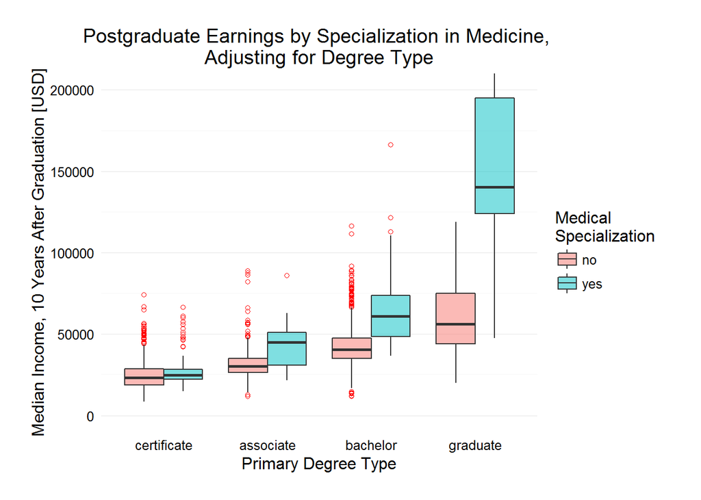

Data from higher education institutions in the U.S. in 2014 has been analyzed to identify potential indicators of postgraduate success. The plot shows distribution of institutions’ median postgraduate earnings by whether the institution specializes in medical and/or health-related education. It shows increasing divergence between medical and non-medical institutions as primary degree level goes up. From this, we can see that: 1) there is positive correlation between an institution’s postgraduate financial success and its specialization in medicine; and 2) this correlation is mediated by the institution’s primary degree type such that the correlation becomes stronger as the degree level goes up. Note that the plot has been zoomed in for better display, so some graduate institutions are not shown.

### Plot Three

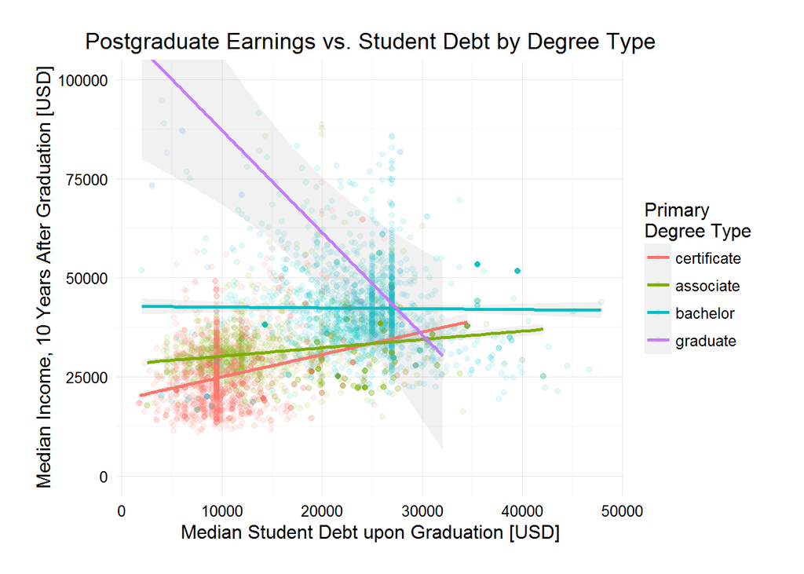

Data from higher education institutions in the U.S. in 2014 has been analyzed to identify potential indicators of postgraduate success. The plot shows the relationship between an institution’s median postgraduate earnings and its median student debt upon graduation. Initial look suggests positive correlation between the two variables. However, after adjusting for primary degree type, we see that the relationship between the two variables are not consistent. Hence, we can tentatively conclude that student debt is not a meaningful indicator of an institution’s postgraduate earnings. Note that the plot has been zoomed in for better display, so some outliers are not shown.

## 2. Reflection

This investigation started with the goal of identifying institution-level indicators of postgraduate financial success in higher education. Analysis results suggest that an institution’s primary degree type/level is a prominent indicator of its postgraduate financial success. In other words, graduates of a higher level educational institution tend to earn more. This is not a much surprising finding as our common experience as well as scholarly research indicate association between a more advanced degree and a greater income. Yet, the current analysis has also revealed that this factor (primary degree type) mediates many other relationships the postgraduate financial success has, such that, when controlled for it (primary degree type), previously observed correlations become much weaker or even disappear.

It needs to be noted that the current analysis and its approach face a major theoretical issue: many characteristics that are collected and examined on the institution level are in fact aggregations of individual-level traits. Therefore, findings pertaining to such characteristics can be in fact findings about the corresponding individual-level traits. For instance, let us assume that we have found positive correlation between an institution’s average SAT or GRE score and postgraduate financial return — even after adjusting for primary degree type. It is then very likely that this correlation is simply a collective-level manifestation of positive correlation between an *individual student’s* SAT/GRE score and *his/her* postgraduate financial success. Hence, additional measures need to be taken to determine whether there still remains something meaningful in the institution-level correlation after accounting for the individual-level correlation. Of course, the surest way for this would be to compare individual students with nearly equal characteristics attending different institutions that also have nearly equal characteristics with one another except in the average SAT/GRE score. If there is found a consistent differentiation among these individual students with respect to postgraduate financial success, then we may conclude that the institution-level correlation captures more than a sum of individual-level correlations. Specifically, we may say that a high-achieving environment has its own positive correlation with postgraduate financial success; or, alternatively, that it *boosts* the positive correlation between an individual student’s SAT/GRE score and his/her postgraduate financial success (which would be referring to an interaction effect).

With this theoretical intricacy in mind, future analysis can examine other variables that could not be covered by the current analysis. One good starting point will be variables relating to the fields of study (i.e. major or concentration), as the current analysis has shown that health-related education is positively correlated with postgraduate financial success. Future analysis can hence probe whether such correlations exist for other particular fields of study such as engineering and law.